# Assignment No 1

# Data Understanding and Exploratory Data Analysis

## Guidelines

- Rename the notebook as **rollnumber_firstname_lastname_PA1**
- It is recommened that you explore the included libraries' documentation when answering the questions.
- You are supposed to answer the question here on Jupyter notebook. Use markdown cells to answer the questions while use code cells to write the code. You can double click on any markdown cell to edit it and press **shift+enter** to execute any code cell.
- Make sure all required figures and tables are visible in the notebook.
- Submit a zip folder containing both the notebook and the html file.

# Task 1: Data Analysis & Preprocessing (25 Marks)

```python
# modify this cell in case more libraries are needed
import pandas as pd
import numpy as np
import seaborn as sns
import matplotlib.pyplot as plt
```

```python
# import data
df = pd.read_csv('property.csv')
df.head(10)
```

|  | property_id | location_id | page_url | property_type | price | location | city | province_name | latitude | longitude | baths | area | purpose | bedrooms | date_added | agency | agent | Area Type | Area Size | Area Category |
| --- | --- | --- | --- | --- | --- | --- | --- | --- | --- | --- | --- | --- | --- | --- | --- | --- | --- | --- | --- | --- |
| 0 | 237062 | 3325 | https://www.zameen.com/Property/g_10_g_10_2_gr... | Flat | 10000000 | G-10 | Islamabad | Islamabad Capital | 33.679890 | 73.012640 | 2 | 4 Marla | For Sale | 2 | 02-04-2019 | NaN | NaN | Marla | 4.0 | 0-5 Marla |
| 1 | 346905 | 3236 | https://www.zameen.com/Property/e_11_2_service... | Flat | 6900000 | E-11 | Islamabad | Islamabad Capital | 33.700993 | 72.971492 | 3 | 5.6 Marla | For Sale | 3 | 05-04-2019 | NaN | NaN | Marla | 5.6 | 5-10 Marla |
| 2 | 386513 | 764 | https://www.zameen.com/Property/islamabad_g_15... | House | 16500000 | G-15 | Islamabad | Islamabad Capital | 33.631486 | 72.926559 | 6 | 8 Marla | For Sale | 5 | 07-17-2019 | NaN | NaN | Marla | 8.0 | 5-10 Marla |
| 3 | 656161 | 340 | https://www.zameen.com/Property/islamabad_bani... | House | 43500000 | Bani Gala | Islamabad | Islamabad Capital | 33.707573 | 73.151199 | 4 | 2 Kanal | For Sale | 4 | 04-05-2019 | NaN | NaN | Kanal | 2.0 | 1-5 Kanal |
| 4 | 841645 | 3226 | https://www.zameen.com/Property/dha_valley_dha... | House | 7000000 | DHA Defence | Islamabad | Islamabad Capital | 33.492591 | 73.301339 | 3 | 8 Marla | For Sale | 3 | 07-10-2019 | Easy Property | Muhammad Junaid Ceo Muhammad Shahid Director | Marla | 8.0 | 5-10 Marla |
| 5 | 850762 | 3390 | https://www.zameen.com/Property/ghauri_town_gh... | House | 34500000 | Ghauri Town | Islamabad | Islamabad Capital | 33.623947 | 73.126588 | 8 | 1.6 Kanal | For Sale | 8 | 04-05-2019 | NaN | NaN | Kanal | 1.6 | 1-5 Kanal |
| 6 | 937975 | 445 | https://www.zameen.com/Property/islamabad_kora... | House | 27000000 | Korang Town | Islamabad | Islamabad Capital | 33.579034 | 73.139591 | 8 | 1 Kanal | For Sale | 8 | 01-04-2019 | NaN | NaN | Kanal | 1.0 | 1-5 Kanal |
| 7 | 1258636 | 3241 | https://www.zameen.com/Property/e_11_e_11_4_ap... | Flat | 7800000 | E-11 | Islamabad | Islamabad Capital | 33.698244 | 72.984238 | 2 | 6.2 Marla | For Sale | 2 | 05-05-2019 | Ettemad Enterprises | Balqiaz Marwat | Marla | 6.2 | 5-10 Marla |
| 8 | 1402466 | 376 | https://www.zameen.com/Property/dha_defence_dh... | House | 50000000 | DHA Defence | Islamabad | Islamabad Capital | 33.540894 | 73.095732 | 7 | 1 Kanal | For Sale | 7 | 10-19-2018 | Easy Property | Muhammad Junaid Ceo Muhammad Shahid Director | Kanal | 1.0 | 1-5 Kanal |
| 9 | 1418706 | 3282 | https://www.zameen.com/Property/f_11_f_11_1_f_... | Penthouse | 40000000 | F-11 | Islamabad | Islamabad Capital | 33.679211 | 72.988787 | 5 | 1 Kanal | For Sale | 5 | 06-27-2019 | Crown Associate | Abrar Ahmed | Kanal | 1.0 | 1-5 Kanal |

### (a) Data Analysis (5 Marks)

We have loaded a dataset for you and it's first 10 rows are printed. All below experiments are to be performed on the variable "df".

**Enlist numerical and categorical attributes.**

> Numerical Attributes : price, baths, latitude, longitude, bedrooms, Area Size

> Categorical Attributes: property_type, location, city, province_name, purpose, agency, agent, Area Type, Area Category, date_added

### (b) Summary Statistics (5 Marks)

```python
# print the summary statistics of the numerical attributes of the data (mean, std, min, 25%, 50%, 75%, max, counts).
stats = df.describe()
stats
```

|  | property_id | location_id | price | latitude | longitude | baths | bedrooms | Area Size |
| --- | --- | --- | --- | --- | --- | --- | --- | --- |
| count | 1.684460e+05 | 168446.000000 | 1.684460e+05 | 168446.000000 | 168446.000000 | 168446.000000 | 168446.000000 | 168446.000000 |
| mean | 1.559626e+07 | 4375.936395 | 1.776576e+07 | 29.859519 | 71.239804 | 2.874227 | 3.179422 | 5.892188 |
| std | 2.251207e+06 | 3776.561581 | 3.531003e+07 | 3.807870 | 3.133042 | 2.463400 | 1.971401 | 5.778327 |
| min | 8.657500e+04 | 1.000000 | 0.000000e+00 | 11.052446 | 25.906027 | 0.000000 | 0.000000 | 0.000000 |
| 25% | 1.488320e+07 | 1058.000000 | 1.750000e+05 | 24.948536 | 67.130363 | 0.000000 | 2.000000 | 3.000000 |
| 50% | 1.665851e+07 | 3286.000000 | 8.500000e+06 | 31.459784 | 73.056182 | 3.000000 | 3.000000 | 5.000000 |
| 75% | 1.708662e+07 | 7220.000000 | 1.950000e+07 | 33.560887 | 73.259870 | 4.000000 | 4.000000 | 8.000000 |
| max | 1.735772e+07 | 14220.000000 | 2.000000e+09 | 73.184088 | 80.161430 | 403.000000 | 68.000000 | 800.000000 |

### (c) Dataframe Size (5 Marks)

```python
# show the number of records (rows) and number of attributes (columns) of the dataframe
records, attributes = df.shape
print("Records (Rows): ", records)
print("Attributes (Columns): ", attributes)
```

```
Records (Rows):  168446
Attributes (Columns):  20
```

### (d) Unique Values (5 Marks)

```python
# print the count of unique entries in (1) Property (2) City and (3) Province
print("1) Property:", df.property_type.unique())
print("2) City:", df.city.unique())
print("3) Province:", df.province_name.unique())
```

```
1) Property: ['Flat' 'House' 'Penthouse' 'Farm House' 'Lower Portion' 'Upper Portion'
 'Room']
2) City: ['Islamabad' 'Lahore' 'Faisalabad' 'Rawalpindi' 'Karachi']
3) Province: ['Islamabad Capital' 'Punjab' 'Sindh']
```

### (e) Missing Entries (5 Marks)

```python
# print the number of missing values in each column
df.isna().sum()
```

```
property_id          0
location_id          0
page_url             0
property_type        0
price                0
location             0
city                 0
province_name        0
latitude             0
longitude            0
baths                0
area                 0
purpose              0
bedrooms             0
date_added           0
agency           44071
agent            44072
Area Type            0
Area Size            0
Area Category        0
dtype: int64
```

# Task 2: Exploratory Data Analysis & Visualization (30 Marks)

### 1.Boxplots (5 Marks)

One of the columns area that you will plot a boxplot for is "area".  
Notice the values are of the format: "x Marla" or "y Kanal".

Normalize the column according the following units:

1 Kanal = 20 Marla  
1 Marla = 272.251 Square Foot

For example: 1.6 Kanal = **8712.032**

```python
# add code to normalize "area"

def normalize_area(value):
    if value.endswith('Marla'):
        x = value[0][0]
        value = int(x)
        return value * (272.251)
    elif value.endswith("Kanal"):
        x = value[0][0]
        value = int(x)
        return value * (20 * 272.251)

for values in df.area.unique():
    df['area'] = df['area'].replace([values], normalize_area(values))
```

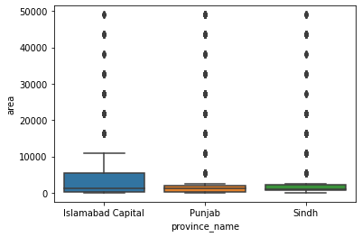

```python
# derive boxplots for "area" after grouping dataset by (1) Province
sns.boxplot(x='province_name', y='area', data=df)
```

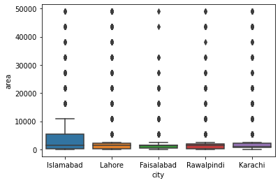

```python
# derive boxplots for "area" after grouping dataset by (2) City
sns.boxplot(x='city', y='area', data=df)
```

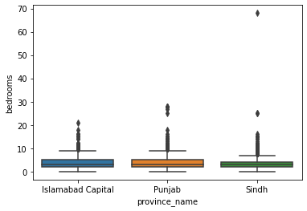

```python
# derive boxplots for "bedrooms" after grouping dataset by (1) Province
sns.boxplot(x='province_name', y='bedrooms', data=df)
```

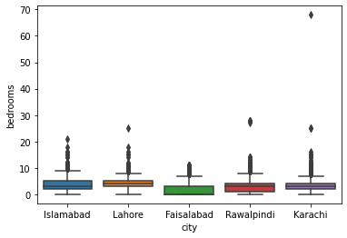

```python
# derive boxplots for "bedrooms" after grouping dataset by (2) City
x = df.groupby( ['city'] )['bedrooms']
sns.boxplot(x='city', y='bedrooms', data=df)
```

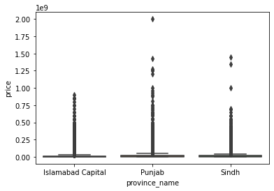

```python
# derive boxplots for "price" after grouping dataset by (1) Province
sns.boxplot(x='province_name', y='price', data=df)
```

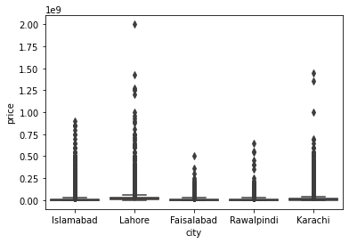

```python
# derive boxplots for "price" after grouping dataset by (2) City
sns.boxplot(x='city', y='price', data=df)
```

### 2. Barplot (5 Marks)

#### (a) Area

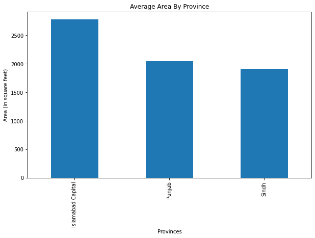

```python
# create a barplot plotting the average area of properties in each province

#All these Barplots are inspired by https://www.statology.org/pandas-groupby-bar-plot/

x = df.groupby( ['province_name'] )['area'].mean()
x.plot(kind='bar', title='Average Area By Province', ylabel='Area (in square feet)', xlabel='Provinces', figsize=(10, 6))
```

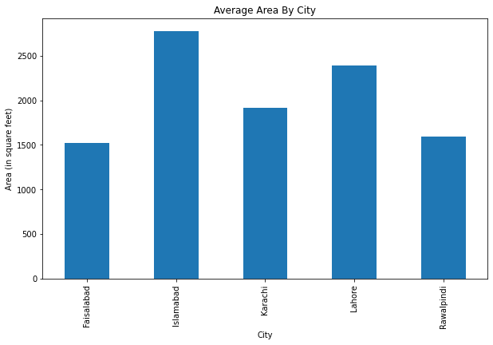

```python
# create a barplot plotting the average area of properties in each city
x = df.groupby( ['city'] )['area'].mean()
x.plot(kind='bar', title='Average Area By City', ylabel='Area (in square feet)', xlabel='City', figsize=(10, 6))
```

#### (b) Price

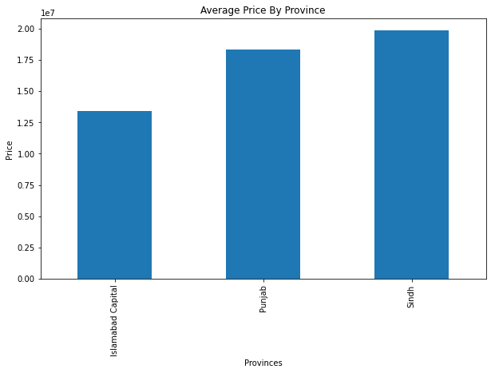

```python
# create a barplot plotting the average price of properties in each province
x = df.groupby( ['province_name'] )['price'].mean()
x.plot(kind='bar', title='Average Price By Province', ylabel='Price', xlabel='Provinces', figsize=(10, 6))
```

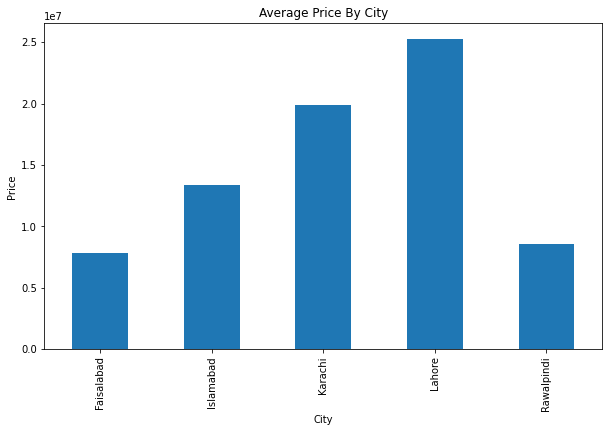

```python
# create a barplot plotting the average price of properties in each city
x = df.groupby( ['city'] )['price'].mean()
x.plot(kind='bar', title='Average Price By City', ylabel='Price', xlabel='City', figsize=(10, 6))
```

#### (c) Bedrooms

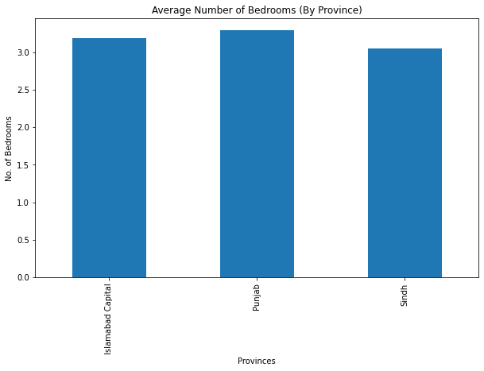

```python
# create a barplot plotting the average number of bedrooms of properties in each province
x = df.groupby( ['province_name'] )['bedrooms'].mean()
x.plot(kind='bar', title='Average Number of Bedrooms (By Province)', ylabel='No. of Bedrooms', xlabel='Provinces', figsize=(10, 6))
```

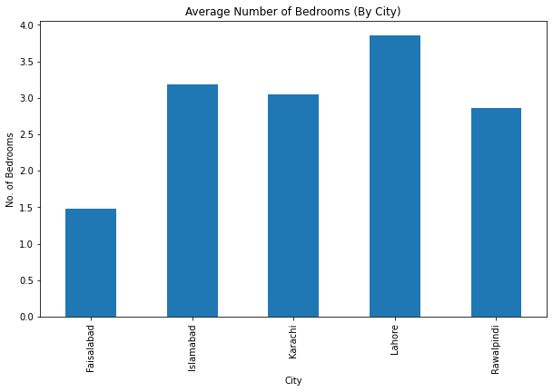

```python
# create a barplot plotting the average number of bedrooms of properties in each city
x = df.groupby( ['city'] )['bedrooms'].mean()
x.plot(kind='bar', title='Average Number of Bedrooms (By City)', ylabel='No. of Bedrooms', xlabel='City', figsize=(10, 6))
```

### 3. Correlation Between Attributes (10 Marks)

#### (a) Correlation

```python
# create a backup for df and drop the columns that are irrelevant in your opinion
mydf = pd.DataFrame(df)
mydf = mydf.drop(['agency', 'page_url','agent','location_id','property_id','Area Category','Area Type','Area Size','longitude','latitude'], axis=1)

##Explanation for removing these attributes:
# Location ID and Property ID - They are simply unique identifiers for every location and property. Not dependant on anything, hence, removed.
# Longitude & Latitude - Not required as we already have more readable attributes like location, city, and province.
# Agency & Agent - Almost 25% missing values in each, and very few unique values.
# Area Category, Area Type, Area Size - Literally the same as Area, just in three different columns instead of one. Even more useless once 'area' was converted to square feet.
# Page URL - Inconsequential as URL is generated randomly on the internet.

mydf
```

|  | property_type | price | location | city | province_name | baths | area | purpose | bedrooms | date_added |
| --- | --- | --- | --- | --- | --- | --- | --- | --- | --- | --- |
| 0 | Flat | 10000000 | G-10 | Islamabad | Islamabad Capital | 2 | 1089.004 | For Sale | 2 | 02-04-2019 |
| 1 | Flat | 6900000 | E-11 | Islamabad | Islamabad Capital | 3 | 1361.255 | For Sale | 3 | 05-04-2019 |
| 2 | House | 16500000 | G-15 | Islamabad | Islamabad Capital | 6 | 2178.008 | For Sale | 5 | 07-17-2019 |
| 3 | House | 43500000 | Bani Gala | Islamabad | Islamabad Capital | 4 | 10890.040 | For Sale | 4 | 04-05-2019 |
| 4 | House | 7000000 | DHA Defence | Islamabad | Islamabad Capital | 3 | 2178.008 | For Sale | 3 | 07-10-2019 |
| ... | ... | ... | ... | ... | ... | ... | ... | ... | ... | ... |
| 168441 | House | 26500000 | Gadap Town | Karachi | Sindh | 0 | 2450.259 | For Sale | 6 | 07-18-2019 |
| 168442 | House | 12500000 | Gadap Town | Karachi | Sindh | 0 | 2178.008 | For Sale | 3 | 07-18-2019 |
| 168443 | House | 27000000 | Gadap Town | Karachi | Sindh | 0 | 2450.259 | For Sale | 6 | 07-18-2019 |
| 168444 | House | 11000000 | Gadap Town | Karachi | Sindh | 0 | 1905.757 | For Sale | 3 | 07-18-2019 |
| 168445 | House | 9000000 | Bahria Town Karachi | Karachi | Sindh | 3 | 2450.259 | For Sale | 3 | 07-18-2019 |

168446 rows × 10 columns

```python
# convert all categorical attributes to numerical attributes (you may use dictionary to map the values to integers).

def categorical(column_name):
    values = mydf[column_name]
    size = len(values.unique())
    lst = []
    for num in range(0, size):
        lst.append(num)
    values = np.array(values.unique())
    mydf[column_name] = mydf[column_name].replace(values, lst)

categorical("property_type")
categorical("location")
categorical("city")
categorical("province_name")
categorical("purpose")
categorical("date_added")
```

```python
# compute correlation
mydf.corr()
```

|  | property_type | price | location | city | province_name | baths | area | purpose | bedrooms | date_added |
| --- | --- | --- | --- | --- | --- | --- | --- | --- | --- | --- |
| property_type | 1.000000 | -0.112190 | 0.008188 | -0.124822 | -0.190470 | -0.092100 | 0.079630 | 0.445256 | -0.112729 | 0.011655 |
| price | -0.112190 | 1.000000 | -0.091530 | 0.007537 | 0.064750 | 0.230205 | 0.464732 | -0.314965 | 0.314145 | -0.020441 |
| location | 0.008188 | -0.091530 | 1.000000 | -0.038915 | -0.022843 | -0.111542 | -0.091769 | -0.074432 | -0.096328 | 0.022883 |
| city | -0.124822 | 0.007537 | -0.038915 | 1.000000 | 0.931164 | -0.113837 | -0.115450 | -0.107245 | -0.095631 | 0.223750 |
| province_name | -0.190470 | 0.064750 | -0.022843 | 0.931164 | 1.000000 | -0.057024 | -0.098354 | -0.246643 | -0.034173 | 0.227366 |
| baths | -0.092100 | 0.230205 | -0.111542 | -0.113837 | -0.057024 | 1.000000 | 0.174185 | -0.136562 | 0.669210 | -0.057584 |
| area | 0.079630 | 0.464732 | -0.091769 | -0.115450 | -0.098354 | 0.174185 | 1.000000 | 0.066378 | 0.217711 | -0.027930 |
| purpose | 0.445256 | -0.314965 | -0.074432 | -0.107245 | -0.246643 | -0.136562 | 0.066378 | 1.000000 | -0.178897 | 0.083024 |
| bedrooms | -0.112729 | 0.314145 | -0.096328 | -0.095631 | -0.034173 | 0.669210 | 0.217711 | -0.178897 | 1.000000 | -0.058572 |
| date_added | 0.011655 | -0.020441 | 0.022883 | 0.223750 | 0.227366 | -0.057584 | -0.027930 | 0.083024 | -0.058572 | 1.000000 |

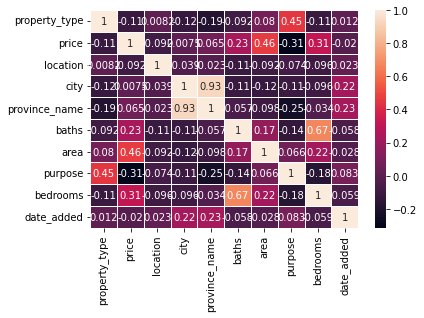

```python
# visualize using heatmap
dataplot = sns.heatmap(mydf.corr(), annot=True, linewidth=.5)
```

> Add comments on the output:

There are some obvious correlations, such as with 'purpose' and 'property type', bedrooms and bathrooms in a house.

Interesting to see that price is not that highly correlated with location, City or even Province which is contrary to the belief that property is generally more expensive in Punjab than, say, Sindh.

#### (b) Chi Square Test

```python
df2 = pd.read_csv('titanic.csv')
df2.head()
```

|  | PassengerId | Survived | Pclass | Name | Sex | Age | SibSp | Parch | Ticket | Fare | Cabin | Embarked |
| --- | --- | --- | --- | --- | --- | --- | --- | --- | --- | --- | --- | --- |
| 0 | 1 | 0 | 3 | Braund, Mr. Owen Harris | male | 22.0 | 1 | 0 | A/5 21171 | 7.2500 | NaN | S |
| 1 | 2 | 1 | 1 | Cumings, Mrs. John Bradley (Florence Briggs Th... | female | 38.0 | 1 | 0 | PC 17599 | 71.2833 | C85 | C |
| 2 | 3 | 1 | 3 | Heikkinen, Miss. Laina | female | 26.0 | 0 | 0 | STON/O2. 3101282 | 7.9250 | NaN | S |
| 3 | 4 | 1 | 1 | Futrelle, Mrs. Jacques Heath (Lily May Peel) | female | 35.0 | 1 | 0 | 113803 | 53.1000 | C123 | S |
| 4 | 5 | 0 | 3 | Allen, Mr. William Henry | male | 35.0 | 0 | 0 | 373450 | 8.0500 | NaN | S |

```python
# compute chi square test for categorical attributes of the imported dataset

# We will take chi squared values repeatedly of many different combinations of attributes. Method inspired by https://www.youtube.com/watch?v=w5iKu1IrTJQ&ab_channel=KrishNaik

import scipy.stats as stats
from scipy.stats import chi2

def chi2Test(attrib1, attrib2):
    ct = pd.crosstab(attrib1, attrib2)
    observed_val = ct.values
    val = stats.chi2_contingency(ct)
    expected_val = val[3]

    num_rows = ct.shape[0]
    num_columns = ct.shape[1]
    degree_freedom = (num_rows - 1) * (num_columns - 1)
    alpha = 0.05

    chi_square=sum([(o-e)**2./e for o,e in zip(observed_val,expected_val)])
    chi_square_statistic = chi_square[0] + chi_square[1]

    p_value = 1 - chi2.cdf(x = chi_square_statistic, df = degree_freedom)
    print('p-value:', p_value)
    print('Alpha / Significance Level: ', alpha)
    print('Degree of Freedom: ', degree_freedom)

    if p_value <= alpha:
        print("Reject Null Hypothesis, there is a relationship")
    else:
        print("Accept Null Hypothesis, there is NO relationship between ")

print("Between PClass and Survived: ")
chi2Test(df2.Pclass, df2.Survived)
print("----------------------------------")

print("Between Embarked and Survived: ")
chi2Test(df2.Embarked, df2.Survived)
print("----------------------------------")

print("Between Sex and Survived: ")
chi2Test(df2.Sex, df2.Survived)
```

```
Between PClass and Survived:
p-value: 0.0
Alpha / Significance Level:  0.05
Degree of Freedom:  2
Reject Null Hypothesis, there is a relationship
----------------------------------
Between Embarked and Survived:
p-value: 1.769922284067249e-06
Alpha / Significance Level:  0.05
Degree of Freedom:  2
Reject Null Hypothesis, there is a relationship
----------------------------------
Between Sex and Survived:
p-value: 0.0
Alpha / Significance Level:  0.05
Degree of Freedom:  1
Reject Null Hypothesis, there is a relationship
```

### 4. Geospatial Analysis (10 Marks)

Use Pakistan's map to plot the location of the properties given in the dataset using the longitude and latitude attributes. Note that this part is very open ended. You can refer to the documentations of the following libraries to achieve this task:

- Matplotlib
- Folium
- GeoPandas
- Plotly

```python
# (optional) you may use the following variables to acquire the coordinates of the corners of the map.
# note that you may need to clear some outliers first

max_lat = df['latitude'].max()
max_lon = df['longitude'].max()

min_lat = df['latitude'].min()
min_lon = df['longitude'].min()

print(max_lat, max_lon, min_lat, min_lon)
```

```
73.184088 80.16143000000001 11.052446 25.906027
```

```python
# add code here
import geopandas as gpd
import folium

#We initialize folium with Central Coordinates of Pakistan
#Using Folium because it creates interactive maps

#Removing Outliers from DataFrame
for val in df.longitude:
    if val > max_lon or val < min_lon:
        df['longitude'] = df['longitude'].replace([val], np.nan)

for val in df.latitude:
        if val > max_lat or val < min_lat:
             df['latitude'] = df['latitude'].replace([val], np.nan)

m = folium.Map(location=[33.738045, 73.084488], tiles='OpenStreetMap', zoom_start=5)
#In this loop, we use all the house coordinates we have and superimpose it on the map.
#Note, we are only plotting 1500 houses for efficiency.
for i in range(1500):
    lat = df.latitude[i]
    long = df.longitude[i]
    prop = df.property_type[i]
    folium.Marker(location=[lat, long], popup = prop, icon = folium.Icon(color='blue')).add_to(m)

m.save('pak.html') #Saving file to be viewed anytime outside of python notebook

m #Showing result here
```

Make this Notebook Trusted to load map: File -> Trust Notebook

[interactive chart not shown]

# Task 3: Dimensionality Reduction (45 Marks)

Dimensionality reduction is a technique in data mining that aims to reduce the number of features (or dimensions) in a dataset while retaining as much information as possible. The goal of dimensionality reduction is to simplify data, remove noise, reduce computational cost, and make it easier to visualize high-dimensional data. Common techniques for dimensionality reduction include principal component analysis (PCA), linear discriminant analysis (LDA), t-distributed stochastic neighbor embedding (t-SNE), and singular value decomposition (SVD). These techniques can be used individually or in combination to transform the original high-dimensional data into a lower-dimensional representation.

```python
# !pip install factor_analyzer --quiet
```

```python
# importing the required libraries

from sklearn.manifold import TSNE
from sklearn.decomposition import PCA
from sklearn.decomposition import NMF
from sklearn.preprocessing import MaxAbsScaler
from sklearn.decomposition import FactorAnalysis
```

Dataset Link: https://archive.ics.uci.edu/ml/machine-learning-databases/wine-quality/

download *winequalitey-red.csv* and *winequality-white.csv* datasets

**a)** Loading and preprocessing (2 Marks)

- Load the red wine dataset
- Create a column with label "red_wine"
- Load the white wine dataset
- Create a column with label "white_wine"
- Combine the both datasets row-wise

```python
# load data and preprocess
red = pd.read_csv('winequality-red.csv', sep=';')
red['wine_type'] = 'Red Wine'
complete = pd.read_csv('winequality-white.csv', sep=';')
complete['wine_type'] = 'White Wine'
complete = pd.concat([red, complete], axis=0)

#We use function from earlier to normalize our new wine-type function
def categorical(column_name):
    values = complete[column_name]
    size = len(values.unique())
    lst = []
    for num in range(0, size):
        lst.append(num)
    values = np.array(values.unique())
    complete[column_name] = complete[column_name].replace(values, lst)

categorical('wine_type')
```

**b)** Now standardize the dataset. Plot the scatter plot using any two attributes. Use different colors for red wine and white wine labels. **(8 Marks)**

```python
# standerdize the dataset
mydf = pd.DataFrame(complete)
object = MaxAbsScaler()
scale = object.fit_transform(mydf)
#We do maxabsscaler on the dataset
standard_df = pd.DataFrame(scale)
standard_df.columns = ['fixed acidity', 'volatile acidity', 'citric acid', 'residual sugar','chlorides', 'free sulfur dioxide', 'total sulfur dioxide', 'density','pH', 'sulphates', 'alcohol', 'quality', 'wine_type']

copy_standard_df = pd.DataFrame(standard_df)
```

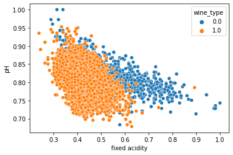

```python
# scatter plot
sns.scatterplot(data = standard_df, x = 'fixed acidity', y = 'pH', hue ='wine_type')
```

t-SNE (t-distributed stochastic neighbor embedding) is a popular dimensionality reduction technique used in data mining and machine learning. It is a non-linear method that projects high-dimensional data into a low-dimensional space while preserving the global structure of the data. t-SNE works by minimizing the divergence between the probability distributions of the similarities between data points in the high-dimensional space and the low-dimensional space.

**c)** Perform t-SNE on the dataset. Now plot the scatter plot for `'fixed acidity'` and `'alcohol'`. Use different colors for red wine and white wine labels. **(8 Marks)**

```python
# Tsne
m = TSNE(learning_rate=50)
tsne_features = m.fit_transform(standard_df)
```

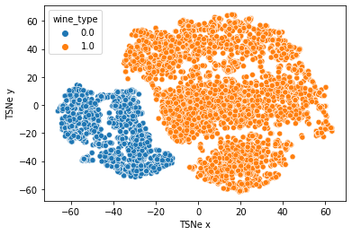

```python
#  Scatterplot
standard_df['TSNe x'] = tsne_features[:,0]
standard_df['TSNe y']= tsne_features[:,1]

sns.scatterplot(data = standard_df, x = 'TSNe x', y = 'TSNe y', hue ='wine_type')
```

PCA (Principal Component Analysis) is a widely used linear dimensionality reduction technique in data mining and machine learning. The goal of PCA is to reduce the number of features in a dataset while retaining as much information as possible.

**d)** Perform PCA on the dataset. Project the input attributes onto the first two principal components and plot the scatter plot for `'fixed acidity'` and `'alcohol'`. Use different colors for red wine and white wine labels. **(8 Marks)**

```python
# PCA
pca = PCA(n_components=2)
pca.fit(copy_standard_df)
pca_features = pca.transform(copy_standard_df)
```

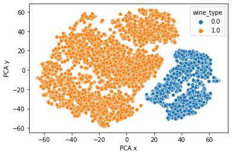

```python
# Scatterplot
standard_df['PCA x'] = pca_features[:,0]
standard_df['PCA y']= pca_features[:,1]
sns.scatterplot(data = standard_df, x = 'PCA x', y = 'PCA y', hue ='wine_type')
```

Non-Negative Matrix Factorization (NNMF) is a dimensionality reduction technique in data mining and machine learning that factorizes a non-negative matrix into two non-negative matrices

**e)** Perform non-negative matrix factorization of the data matrix to 2-D and plot the scatter plot again for these (new) attributes. **(8 Marks)**

```python
# NMF
copy_standard_df = copy_standard_df.drop(['TSNe x', 'TSNe y'], axis=1) #Dropping these as they were automatically
#to the copy of standard dataset on my PC. If the same does not happen on your system then comment this line out. THANKSS!!!
nmf = NMF(n_components=2)
nmf.fit(copy_standard_df)
nmf_features = nmf.transform(copy_standard_df)
```

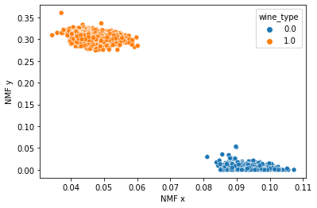

```python
# Scatterplot
standard_df['NMF x'] = nmf_features[:,0]
standard_df['NMF y']= nmf_features[:,1]
sns.scatterplot(data = standard_df, x = 'NMF x', y = 'NMF y', hue ='wine_type')
```

Factor Analysis is a statistical technique used for dimensionality reduction and pattern recognition in data mining and machine learning. It aims to explain the correlations between variables in a dataset by identifying a smaller number of underlying factors or latent variables.

**f)** Perfrom factor analysis to find two factors for the dataset. Plot the scatter plot again for these (new) attributes. **(8 Marks)**

```python
#  Factor Analysis
fa = FactorAnalysis(n_components=2)
fa.fit(copy_standard_df)
fa_features = fa.transform(copy_standard_df)
```

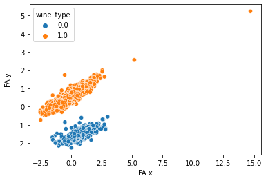

```python
# Scatterplot
standard_df['FA x'] = fa_features[:,0]
standard_df['FA y']= fa_features[:,1]
sns.scatterplot(data = standard_df, x = 'FA x', y = 'FA y', hue ='wine_type')
```

**g)** Comment on the results obtained. **(3 Marks)**

NNMF can only work on positive values hence we chose the Maximun Absolute Value (MaxAbsScaler) as it gives positive values for the most part so that NNMF can run properly. However, NNMF excelelnt results as it can be seen to have no overlap between the two wine types which is not ideal.